# MEDICAL INSURANCE DATA ANALYSIS PROJECT

KILWAKE

2026-05-21

## SETTING WORKING DIRECTORY

```r
setwd("C:/Users/HomePC/Desktop/e-commerce project")
```

### DATA IMPORTATION

```r
insurance_data<-read.csv("insurance_data.csv")
head(insurance_data)
```

```
##   age    sex    bmi children smoker    region   charges
## 1  19 female 27.900        0    yes southwest 16884.924
## 2  18   male 33.770        1     no southeast  1725.552
## 3  28   male 33.000        3     no southeast  4449.462
## 4  33   male 22.705        0     no northwest 21984.471
## 5  32   male 28.880        0     no northwest  3866.855
## 6  31 female 25.740        0     no southeast  3756.622
```

## structure

```r
str(insurance_data)
```

```
## 'data.frame':    1338 obs. of  7 variables:
##  $ age     : int  19 18 28 33 32 31 46 37 37 60 ...
##  $ sex     : chr  "female" "male" "male" "male" ...
##  $ bmi     : num  27.9 33.8 33 22.7 28.9 ...
##  $ children: int  0 1 3 0 0 0 1 3 2 0 ...
##  $ smoker  : chr  "yes" "no" "no" "no" ...
##  $ region  : chr  "southwest" "southeast" "southeast" "northwest" ...
##  $ charges : num  16885 1726 4449 21984 3867 ...
```

### missing values

```r
missing_value<-sum(is.na(insurance_data))
print(missing_value)
```

```
## [1] 0
```

## removing duplicates

```r
duplicated_values<-sum(duplicated(insurance_data))
print(duplicated_values)
```

```
## [1] 1
```

```r
library(dplyr)
insurance_data <- distinct(insurance_data)
```

```r
duplicated_values<-sum(duplicated(insurance_data))
print(duplicated_values)
```

```
## [1] 0
```

```r
unique(insurance_data$sex)
```

```
## [1] "female" "male"
```

### detecting outlier

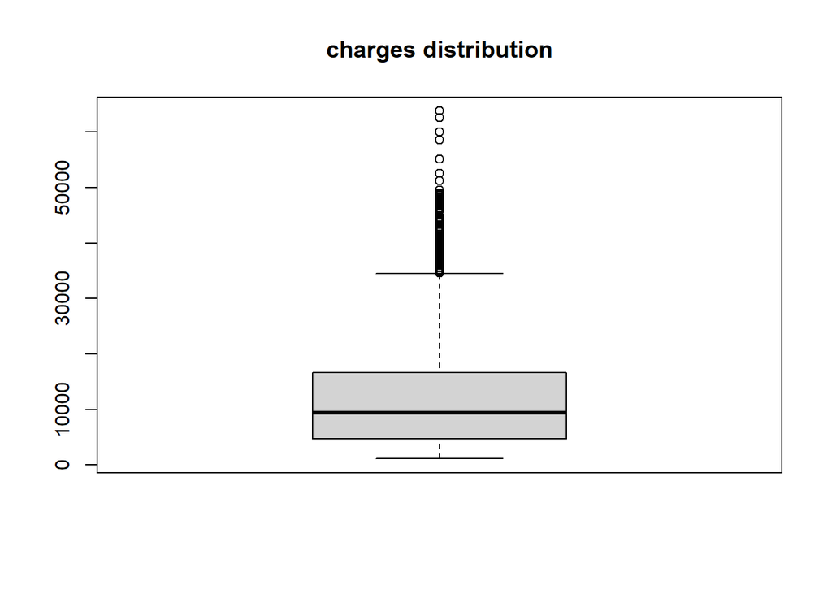

```r
boxplot(insurance_data$charges,main="charges distribution")
```

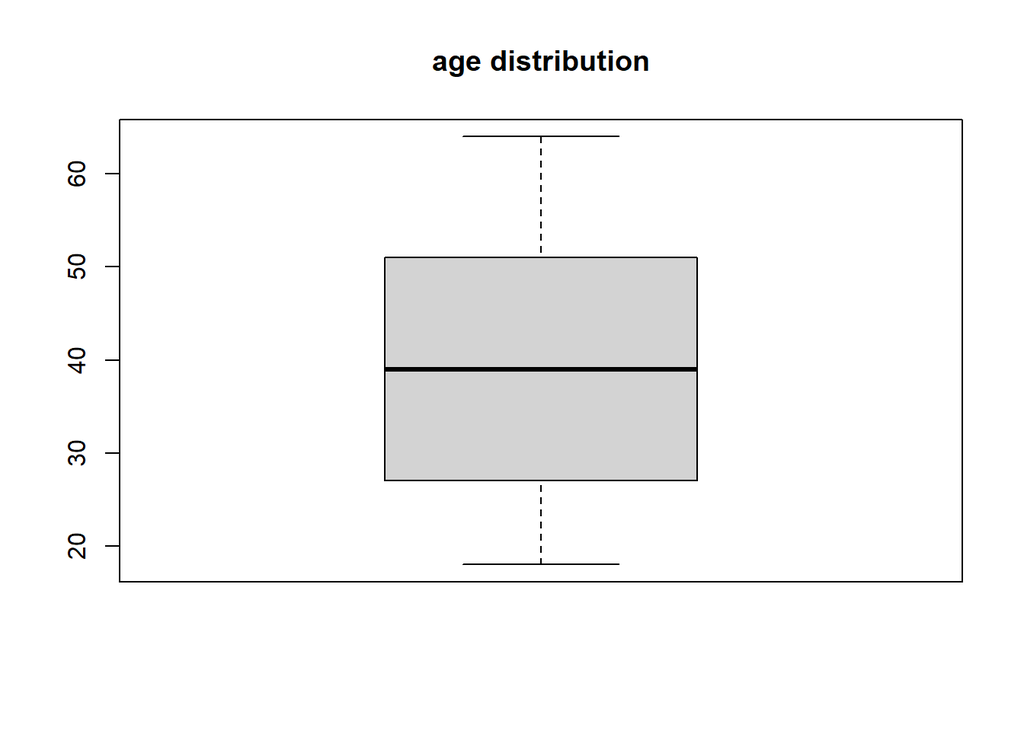

```r
boxplot(insurance_data$age, main = "age distribution")
```

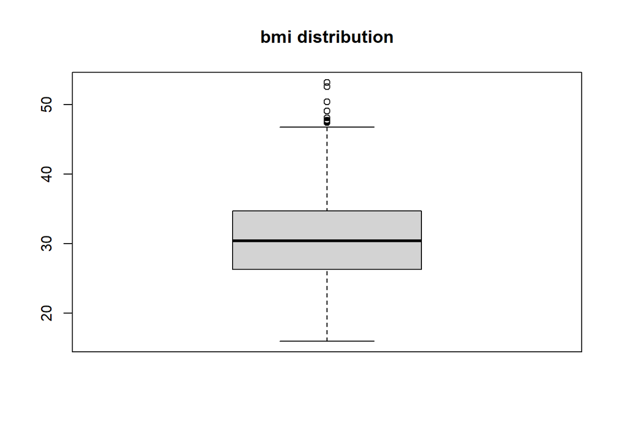

```r
boxplot(insurance_data$bmi,main="bmi distribution")
```

#### treating outliers

```r
Q1 <- quantile(insurance_data$charges, 0.25)
Q3 <- quantile(insurance_data$charges, 0.75)
IQR <- Q3 - Q1
lower_bound <- Q1 - 1.5 * IQR
upper_bound <- Q3 + 1.5 * IQR

d_cleaned <-insurance_data[insurance_data$charges >=lower_bound &insurance_data$charges <=upper_bound,]
```

```r
Q1 <- quantile(d_cleaned$bmi, 0.25,na.rm = TRUE)
Q3 <- quantile(d_cleaned$bmi, 0.75,na.rm = TRUE)
IQR <- Q3 - Q1
lower_bound <- Q1 - 1.5 * IQR
upper_bound <- Q3 + 1.5 * IQR

d_cleaned <-d_cleaned[d_cleaned$bmi>=lower_bound &d_cleaned$bmi<=upper_bound,]
```

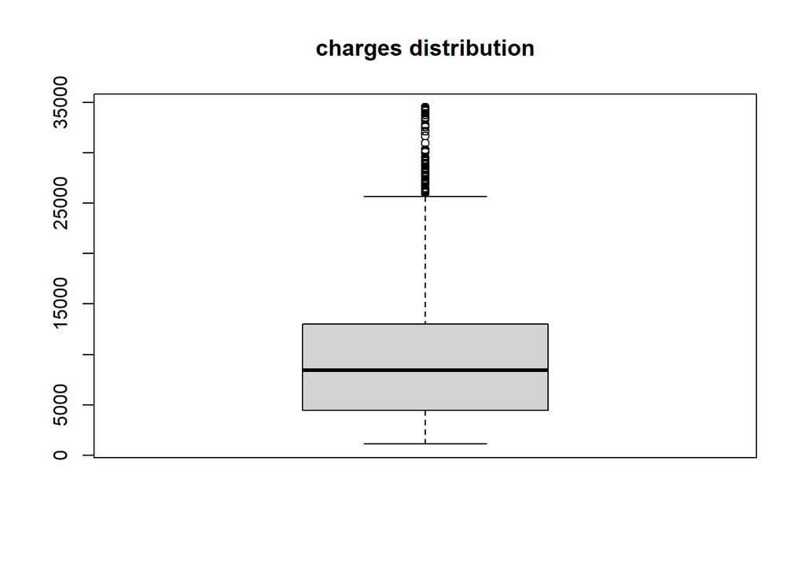

```r
boxplot(d_cleaned$charges,main="charges distribution")
```

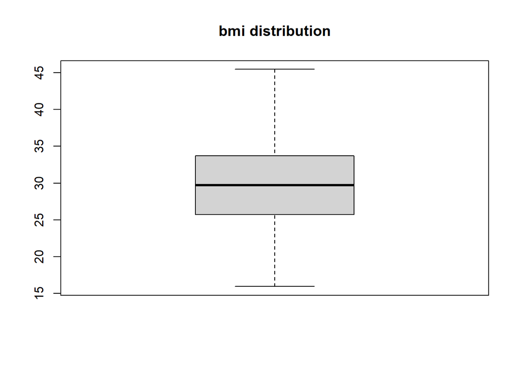

```r
boxplot(d_cleaned$bmi,main="bmi distribution")
```

```r
Q1 <- quantile(d_cleaned$charges, 0.25,na.rm = TRUE)
Q3 <- quantile(d_cleaned$charges, 0.75,na.rm = TRUE)
IQR <- Q3 - Q1
lower_bound <- Q1 - 1.5 * IQR
upper_bound <- Q3 + 1.5 * IQR

g_cleaned <-d_cleaned[d_cleaned$charges >=lower_bound &d_cleaned$charges <=upper_bound,]
```

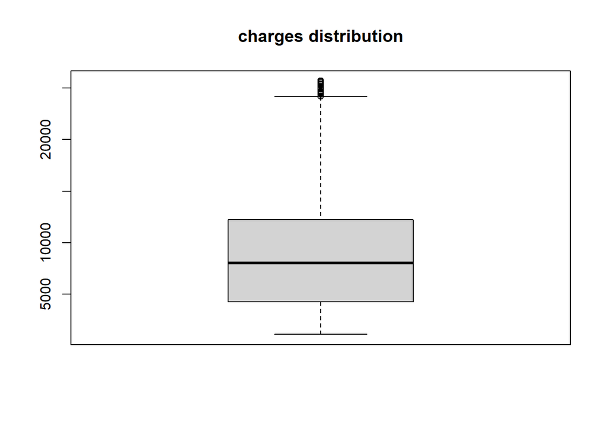

```r
boxplot(g_cleaned$charges,main="charges distribution")
```

```r
Q1 <-quantile(g_cleaned$charges, 0.25,na.rm = TRUE)
Q3 <- quantile(g_cleaned$charges, 0.75,na.rm = TRUE)
IQR <- Q3 - Q1
lower_bound <- Q1 - 1.5 * IQR
upper_bound <- Q3 + 1.5 * IQR

g_cleaned <-g_cleaned[g_cleaned$charges >=lower_bound &g_cleaned$charges <=upper_bound,]
```

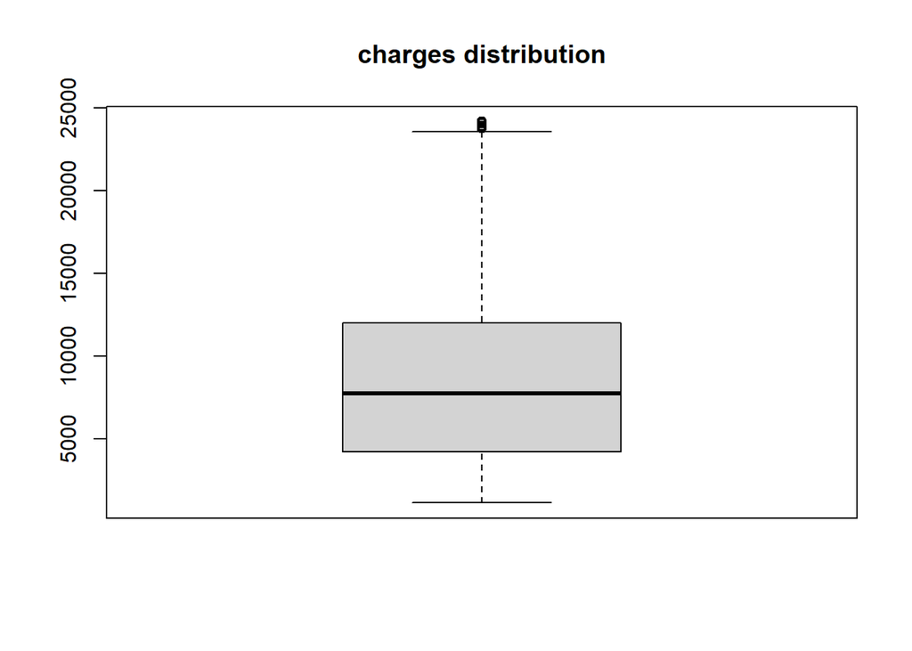

```r
boxplot(g_cleaned$charges,main="charges distribution")
```

```r
Q1 <-quantile(g_cleaned$charges, 0.25,na.rm = TRUE)
Q3 <- quantile(g_cleaned$charges, 0.75,na.rm = TRUE)
IQR <- Q3 - Q1
lower_bound <- Q1 - 1.5 * IQR
upper_bound <- Q3 + 1.5 * IQR

h_cleaned <-g_cleaned[g_cleaned$charges >=lower_bound &g_cleaned$charges <=upper_bound,]
```

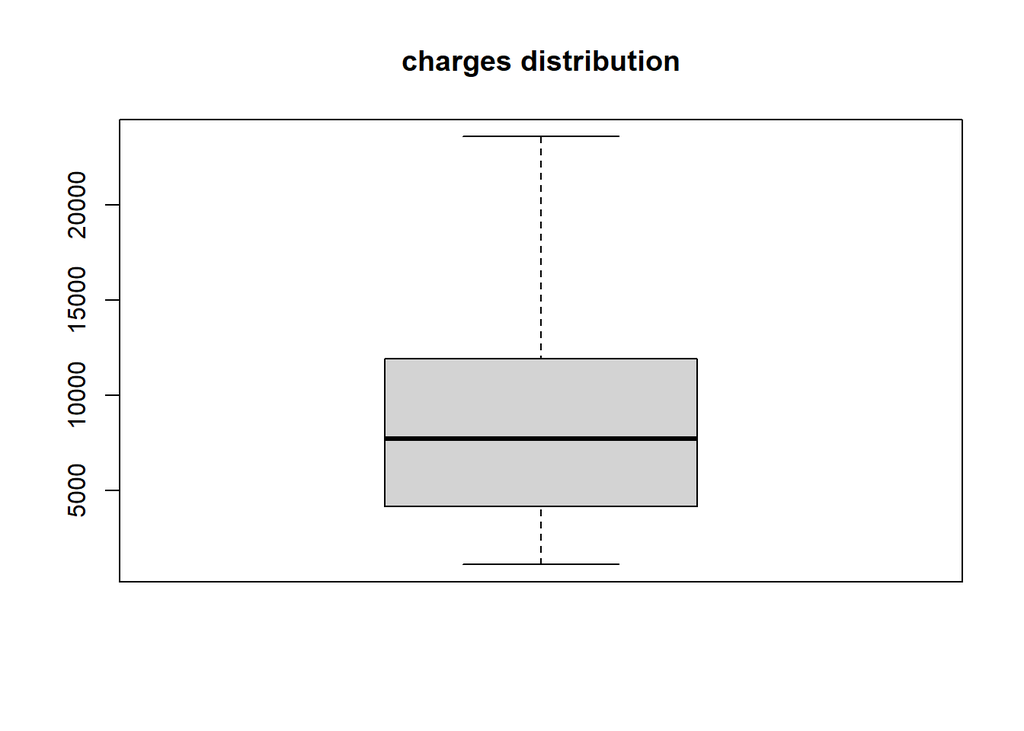

```r
boxplot(h_cleaned$charges,main="charges distribution")
```

```r
unique(h_cleaned$children)
```

```
## [1] 0 1 3 2 5 4
```

## DATA MANUPULATION

```r
 library(dplyr)

h_cleaned <- h_cleaned %>%
  mutate(age_group = case_when(
    age < 20 ~ "Young",
    age >= 20 & age <= 35 ~ "Youth",
    age >= 36 & age <= 59 ~ "Adult",
    age >= 60 ~ "Old"
  ))
head(h_cleaned)
```

```
##   age    sex    bmi children smoker    region   charges age_group
## 1  19 female 27.900        0    yes southwest 16884.924     Young
## 2  18   male 33.770        1     no southeast  1725.552     Young
## 3  28   male 33.000        3     no southeast  4449.462     Youth
## 4  33   male 22.705        0     no northwest 21984.471     Youth
## 5  32   male 28.880        0     no northwest  3866.855     Youth
## 6  31 female 25.740        0     no southeast  3756.622     Youth
```

```r
library(dplyr)

h_cleaned_processed1 <- h_cleaned %>%
  mutate(bmi_category = case_when(
    bmi < 18.5 ~ "Underweight",
    bmi >= 18.5 & bmi <= 24.9 ~ "Normal",
    bmi >= 25 & bmi <= 29.9 ~ "Overweight",
    bmi >= 30 ~ "Obese"
  ))
head(h_cleaned_processed1)
```

```
##   age    sex    bmi children smoker    region   charges age_group bmi_category
## 1  19 female 27.900        0    yes southwest 16884.924     Young   Overweight
## 2  18   male 33.770        1     no southeast  1725.552     Young        Obese
## 3  28   male 33.000        3     no southeast  4449.462     Youth        Obese
## 4  33   male 22.705        0     no northwest 21984.471     Youth       Normal
## 5  32   male 28.880        0     no northwest  3866.855     Youth   Overweight
## 6  31 female 25.740        0     no southeast  3756.622     Youth   Overweight
```

```r
h_cleaned_processed1 <- h_cleaned_processed1[!is.na(h_cleaned_processed1$bmi_category), ]
```

```r
h_filtered <- h_cleaned_processed1 %>%
  filter(smoker == "yes", age > 30) %>%
  arrange(desc(charges))

h_filtered
```

```
##    age    sex    bmi children smoker    region  charges age_group bmi_category
## 1   48   male 28.000        1    yes southwest 23568.27     Adult   Overweight
## 2   47 female 26.125        1    yes northeast 23401.31     Adult   Overweight
## 3   49   male 25.600        2    yes southwest 23306.55     Adult   Overweight
## 4   53 female 22.880        1    yes southeast 23244.79     Adult       Normal
## 5   47 female 27.830        0    yes southeast 23065.42     Adult   Overweight
## 6   43 female 26.700        2    yes southwest 22478.60     Adult   Overweight
## 7   56   male 19.950        0    yes northeast 22412.65     Adult       Normal
## 8   40 female 28.120        1    yes northeast 22331.57     Adult   Overweight
## 9   51   male 23.210        1    yes southeast 22218.11     Adult       Normal
## 10  42   male 30.000        0    yes southwest 22144.03     Adult        Obese
## 11  47   male 25.410        1    yes southeast 21978.68     Adult   Overweight
## 12  43 female 24.700        2    yes northwest 21880.82     Adult       Normal
## 13  43 female 26.885        0    yes northwest 21774.32     Adult   Overweight
## 14  43 female 25.270        1    yes northeast 21771.34     Adult   Overweight
```

[output cut: 35 more lines]

```r
h_cleaned_processed1 %>%
  group_by(region) %>%
  summarise(
    Min_Charges = min(charges, na.rm = TRUE),
    Max_Charges = max(charges, na.rm = TRUE)
  )
```

```
## # A tibble: 4 × 3
##   region    Min_Charges Max_Charges
##   <chr>           <dbl>       <dbl>
## 1 northeast       1695.      23401.
## 2 northwest       1621.      22494.
## 3 southeast       1122.      23563.
## 4 southwest       1242.      23568.
```

## DATA VISUALIZATION

```r
summary(h_cleaned_processed1)
```

```
##       age               sex            bmi           children
##  Min.   :18.00   Length   :1093   Min.   :15.96   Min.   :0.000
##  1st Qu.:26.00   N.unique :   2   1st Qu.:25.75   1st Qu.:0.000
##  Median :38.00   N.blank  :   0   Median :29.70   Median :1.000
##  Mean   :38.49   Min.nchar:   4   Mean   :29.97   Mean   :1.074
##  3rd Qu.:50.00   Max.nchar:   6   3rd Qu.:33.88   3rd Qu.:2.000
##  Max.   :64.00                    Max.   :45.43   Max.   :5.000
##        smoker           region        charges          age_group
##  Length   :1093   Length   :1093   Min.   : 1122   Length   :1093
##  N.unique :   2   N.unique :   4   1st Qu.: 4185   N.unique :   4
##  N.blank  :   0   N.blank  :   0   Median : 7731   N.blank  :   0
##  Min.nchar:   2   Min.nchar:   9   Mean   : 8626   Min.nchar:   3
##  Max.nchar:   3   Max.nchar:   9   3rd Qu.:11931   Max.nchar:   5
##                                    Max.   :23568
##     bmi_category
##  Length   :1093
##  N.unique :   4
##  N.blank  :   0
##  Min.nchar:   5
##  Max.nchar:  11
##
```

## Histogram

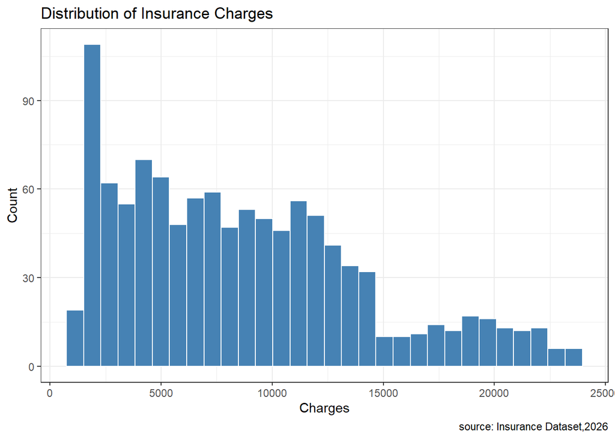

```r
library(ggplot2)

ggplot(h_cleaned_processed1, aes(x = charges)) +
  geom_histogram(bins = 30, fill = "steelblue", color = "white") +
  labs(title = "Distribution of Insurance Charges", x = "Charges", y = "Count",
   caption = "source: Insurance Dataset,2026")+

  theme_bw()
```

### Report of the histogram above

The distribution of insurance charges is right-skewed, with most charges concentrated at lower values and a long tail extending toward higher charges. This suggests that while the majority of individuals incur moderate healthcare expenses, a smaller proportion experience substantially higher medical costs. There also appears to be a small secondary concentration of charges at higher values, which may indicate the influence of specific risk factors such as smoking or obesity.

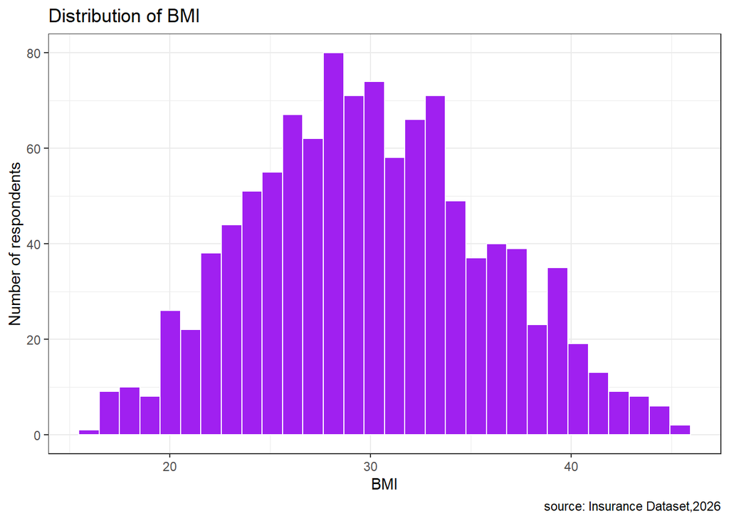

```r
library(ggplot2)

ggplot(h_cleaned_processed1, aes(x = bmi)) +
  geom_histogram(bins = 30, fill = "purple", color = "white") +
  labs(title = "Distribution of BMI", x = "BMI", y = "Number of respondents",
   caption = "source: Insurance Dataset,2026")+

  theme_bw()
```

The histogram shows the distribution of BMI among respondents in the insurance dataset. Most respondents have BMI values between 25 and 35, with the highest concentration around 30. This indicates that many individuals fall within the overweight category. Very low and very high BMI values are less common, showing that extreme BMI levels are rare in the dataset. Overall, the distribution appears approximately normal with moderate variation in BMI values.

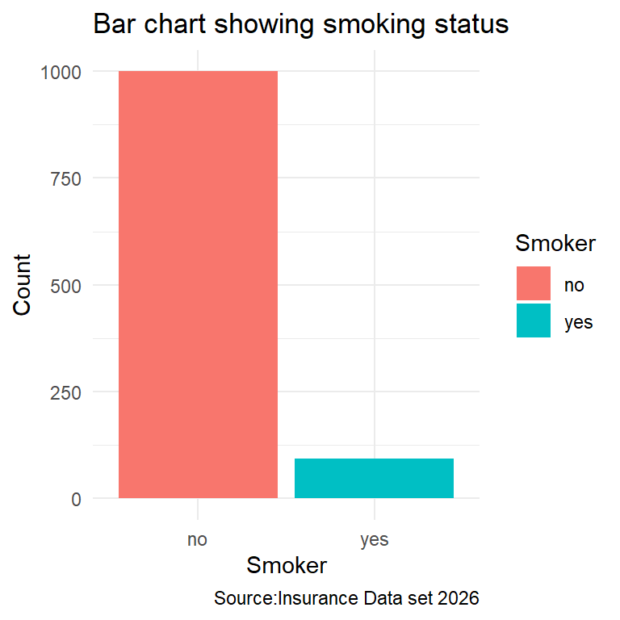

```r
library(ggplot2)

ggplot(h_cleaned_processed1, aes(x = smoker, fill = smoker)) +
  geom_bar() +
  labs(title = "Bar chart showing smoking status", x = "Smoker", y = "Count", fill = "Smoker",
       caption = "Source:Insurance Data set 2026") +
  theme_minimal()
```

### Report of smokers

Non-smokers make the largest number in the data set

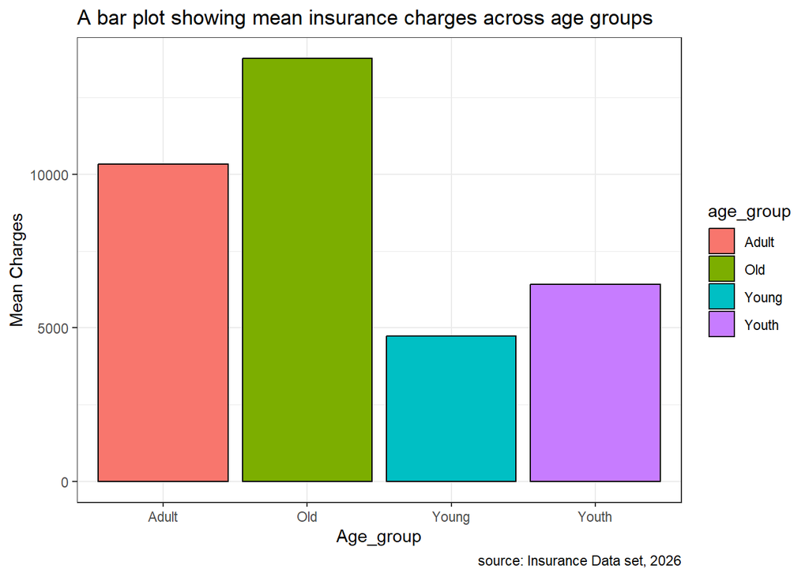

```r
h_cleaned_processed1 %>%
  group_by(age_group) %>%
  summarise(mean_charges = mean(charges)) %>%
  ggplot(aes(x = age_group, y = mean_charges, fill = age_group)) +
  geom_bar(stat = "identity", color = "black") +
  labs(x = "Age_group",
       y = "Mean Charges",
       title = "A bar plot showing mean insurance charges across age groups",
       caption = "source: Insurance Data set, 2026") +
  theme_bw()
```

### report of the bar plot

From the results old consumes more insurance(ages over 60 ) followed by adults(ages between 35 and 59),the young consumes less insurance

### pie chart of charges per region

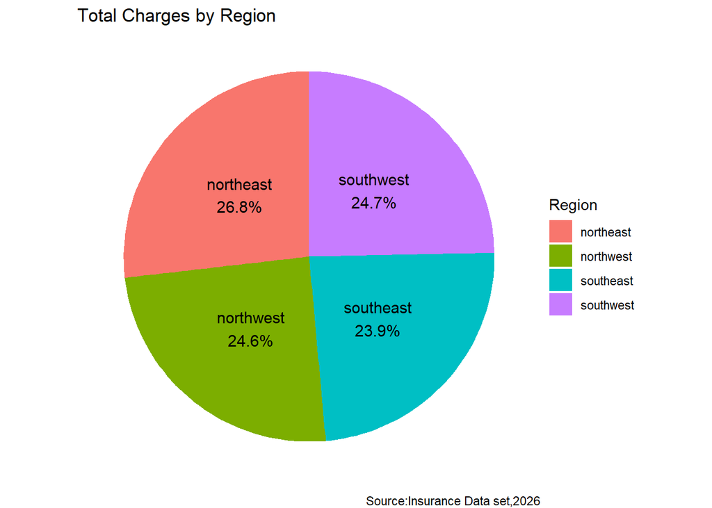

```r
library(ggplot2)
library(dplyr)

h_cleaned_processed1 |>
  group_by(region) |>
  summarise(total_charges = sum(charges)) |>
  mutate(pct = total_charges / sum(total_charges),
         label = paste0(region, "\n", scales::percent(pct, accuracy = 0.1))) |>
  ggplot(aes(x = "", y = total_charges, fill = region)) +
  geom_col(width = 1) +
  coord_polar(theta = "y") +
  geom_text(aes(label = label), position = position_stack(vjust = 0.5), size = 4) +
  labs(title = "Total Charges by Region", fill = "Region",caption = "Source:Insurance Data set,2026"
       ) +
  theme_void()
```

#### report of the pie chart The pie chart shows the northeast region accounts for the largest share of total charges at 26.8%, while the other three regions (northwest 24.6%, southwest 24.7%, southeast 23.9%) are fairly evenly splilt